# Análisis de los residuos

# Introducción

Este documento es la continuación de:

1. C:/Prog/tesis/1_Primeros_pasos.Rmd
2. C:/Prog/tesis/INEGI-2023_Conociendo-ENOE.Rmd
3. C:/Prog/tesis/2_Analisis_exploratorio_datos1.Rmd
4. C:/Prog/tesis/3_Limpieza_datos.Rmd
5. C:/Prog/tesis/4_Panorama_jovenes.Rmd
6. C:/Prog/tesis/5_Sobre-educacion.Rmd
7. C:/Prog/tesis/5_Sobre-educacion_2.Rmd
8. C:/Prog/tesis/5_Sobre-educacion_3.Rmd
9. C:/Prog/tesis/5_Sobre-educacion_4.Rmd
10. C:/Prog/tesis/5_Sobre-educacion_5.Rmd
11. C:/Prog/tesis/6_Efecto_salarial_1.Rmd
12. C:/Prog/tesis/6_Efecto_salarial_2.Rmd

El objetivo es verificar que los residuos cumplan con los supuestos clásicos del modelo de regresión:

1. Media cero
2. Homocedasticidad: misma varianza
3. No correlación
4. Independencia lineal

# Instalación

Según [Chat GPT](https://chatgpt.com/s/t_690cff8c2f808191bcd4f8a034615540), se deben instalar los siguientes paquetes:

```r
# gráficos
# system.file(package = "performance")
# system.file(package = "car")
# install.packages("performance", dependencies = TRUE)
# install.packages("car", dependencies = TRUE)

# test de normalidad
# system.file(package = "stats")
# system.file(package = "nortest")
# system.file(package = "moments")

# test de homocedasticidad
# system.file(package = "lmtest")
# system.file(package = "car")

# test de autocorrelación
# system.file(package = "lmtest")

# diagnóstico global
# system.file(package = "performance")
# system.file(package = "see")
# install.packages("see", dependencies = TRUE)

library(tidyverse)
library(performance)
library(car)
library(stats)
library(nortest)
library(moments)
library(lmtest)
library(see)
```

# Paquete `gujarati`

Se utilizará los datos que muestra Arias-García(2021) para realizar el ejemplo. Cabe señalar que el autor extrajó los datos de Gujarati, según [brunoruas](https://github.com/brunoruas2/gujarati) existe un paquete que contiene dichos datos. Vamos a validar.

```r
devtools::install_github('https://github.com/brunoruas2/gujarati')
```

De acuerdo con Arias-García(2021), los datos provienen de la tabla 3-2

| obs | Mean.Hourly.Wage | Years.of.Schooling |
| --- | --- | --- |
| 1 | 4.4567 | 6 |
| 2 | 5.77 | 7 |
| 3 | 5.9787 | 8 |
| 4 | 7.3317 | 9 |
| 5 | 7.3182 | 10 |
| 6 | 6.5844 | 11 |
| 7 | 7.8182 | 12 |
| 8 | 7.8351 | 13 |
| 9 | 11.0223 | 14 |
| 10 | 10.6738 | 15 |

[output cut: 3 more lines]

Sí se encuentran los datos en el paquete `gujarati` (Pd. me encanta R). Realicemos la regresión. Pero primero, cambiemos el tipo de variable de factor a númerico.

# Segmentar variables

```r
df <- as_tibble(gujarati::Table3_2)

df %>%
  transmute(
    obs = as.integer(obs),
    salario = as.double(Mean.Hourly.Wage),
    escolaridad = as.double(Years.of.Schooling)
  )
```

| obs | salario | escolaridad |
| --- | --- | --- |
| 1 | 6 | 10 |
| 6 | 7 | 11 |
| 7 | 8 | 12 |
| 8 | 11 | 13 |
| 9 | 10 | 1 |
| 10 | 9 | 2 |
| 11 | 12 | 3 |
| 12 | 13 | 4 |
| 13 | 3 | 5 |
| 2 | 1 | 6 |

[output cut: 3 more lines]

Como se observa, al momento de convertir de factor a número los valores no coinciden ¿por qué?

Después de leer la sección de convertir de factor a número, regresando a nuestro ejemplo:

```r
df <- as_tibble(gujarati::Table3_2)

df %>%
  transmute(
    obs = as.integer(levels(obs))[obs],
    salario = as.double(levels(Mean.Hourly.Wage))[Mean.Hourly.Wage],
    escolaridad = as.integer(levels(Years.of.Schooling))[Years.of.Schooling]
  )
```

| obs | salario | escolaridad |
| --- | --- | --- |
| 1 | 4.4567 | 6 |
| 2 | 5.7700 | 7 |
| 3 | 5.9787 | 8 |
| 4 | 7.3317 | 9 |
| 5 | 7.3182 | 10 |
| 6 | 6.5844 | 11 |
| 7 | 7.8182 | 12 |
| 8 | 7.8351 | 13 |
| 9 | 11.0223 | 14 |
| 10 | 10.6738 | 15 |

[output cut: 3 more lines]

Ahora ya coincide.

```r
df <- as_tibble(gujarati::Table3_2)

df <- df %>%
  transmute(
    obs = as.integer(levels(obs))[obs],
    salario = as.double(levels(Mean.Hourly.Wage))[Mean.Hourly.Wage],
    escolaridad = as.integer(levels(Years.of.Schooling))[Years.of.Schooling]
  )
```

# Regresión

```r
modelo <- lm(salario ~ escolaridad, data = df)
summary.lm(modelo)
```

```
Call:
lm(formula = salario ~ escolaridad, data = df)

Residuals:
    Min      1Q  Median      3Q     Max
-1.5637 -0.7350  0.1266  0.7158  1.3198

Coefficients:
            Estimate Std. Error t value Pr(>|t|)
(Intercept) -0.01445    0.87462  -0.017    0.987
escolaridad  0.72410    0.06958  10.406 4.96e-07 ***
---
Signif. codes:  0 ‘***’ 0.001 ‘**’ 0.01 ‘*’ 0.05 ‘.’ 0.1 ‘ ’ 1

Residual standard error: 0.9387 on 11 degrees of freedom
Multiple R-squared:  0.9078,    Adjusted R-squared:  0.8994
F-statistic: 108.3 on 1 and 11 DF,  p-value: 4.958e-07
```

# Análisis gráfico

## Gráficos base de R

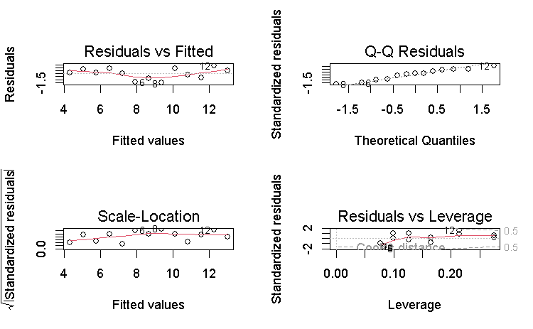

```r
par(mfrow = c(2, 2))
plot(modelo)
```

## Con `ggplot2` y `performance`

[figure not shown]

```r
performance::check_model(modelo)
```

## QQ plot manual con `ggplot`

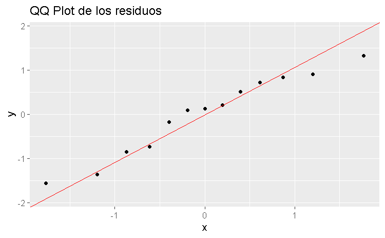

```r
ggplot(data.frame(res = resid(modelo)), aes(sample = res)) +
  stat_qq() +
  stat_qq_line(color = "red") +
  labs(title = "QQ Plot de los residuos")
```

## Individual

### Normalidad

#### Histograma

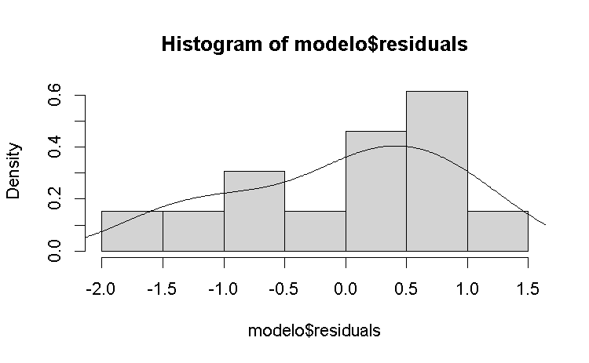

```r
hist(modelo$residuals, prob = TRUE)
lines(density(modelo$residuals))
```

#### QQ plot manual con `plot`

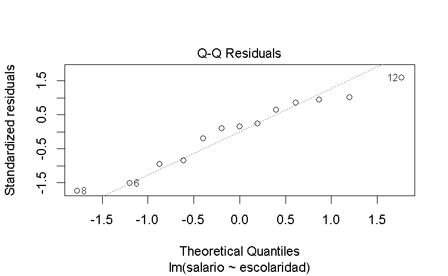

### Homocedasticidad

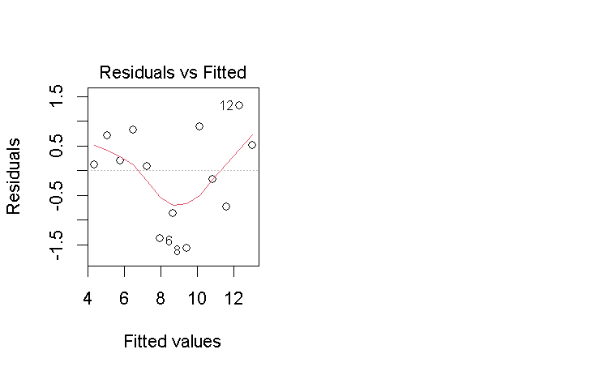

```r
par(mfrow = c(1, 2))
plot(modelo, 1)
plot(modelo, 3)
```

## Autocorrelación

[figure not shown]

```r
par(mfrow = c(1, 2))
plot(modelo, 1)
plot(modelo, 3)
```

# Pruebas estadísticas

## Normalidad

```r
# Shapiro-Wilk
shapiro.test(resid(modelo))
```

```
    Shapiro-Wilk normality test

data:  resid(modelo)
W = 0.94963, p-value = 0.5926
```

```r
# Anderson-Darling
nortest::ad.test(resid(modelo))
```

```
    Anderson-Darling normality test

data:  resid(modelo)
A = 0.28873, p-value = 0.5576
```

```r
# Jarque-Bera
moments::jarque.test(resid(modelo))
```

```
    Jarque-Bera Normality Test

data:  resid(modelo)
JB = 0.8287, p-value = 0.6608
alternative hypothesis: greater
```

## Homocedasticidad

```r
# Breusch-Pagan
lmtest::bptest(modelo)
```

```
    studentized Breusch-Pagan test

data:  modelo
BP = 0.91274, df = 1, p-value = 0.3394
```

```r
# Test de varianza no constante ¿?
car::ncvTest(modelo)
```

```
Non-constant Variance Score Test
Variance formula: ~ fitted.values
Chisquare = 0.4774789, Df = 1, p = 0.48957
```

## Autocorrelación

```r
# Durbin-Watson
lmtest::dwtest(modelo)
```

[output not shown]

# ¿Cómo interpretar las pruebas estadísticas?

## Normalidad

- Shapiro-Wilk: $H_0$: los residuos se distribuyen normalmente,
- Anderson-Darling: $H_0$: los residuos se distribuyen normalmente,
- Jarque-Bera: $H_0$: los residuos se distribuyen normalmente

## Homocedasticidad

- Breusch-Pagan: $H_0$ varianza constante (homocedasticidad) en los residuos
- Varianza no constante $H_0$ homocedasticidad

## No autocorrelación

- Durbin-Watson $H_0$: no hay autocorrelación de primer orden

## p-value

Recuerda:

- Si `p-value` < 0.05 se rechaza la hipótesis nula ($H_0),
- Si `p-value` > 0.05 no se rechaza la hipótesis nula ($H_0),

# ¿Cómo convertir un factor a número con `mutate`?

```r
# library(dplyr)

# Crear un data frame de ejemplo
df2 <- tibble(
  mi_factor = factor(c("100", "200", "300", "100", "200"))
  # mi_otro_factor = factor(c("X", "Y", "X", "Z", "Y"))
)

# Método 1: Usar los niveles del factor para obtener los valores numéricos correctos
df2 <- df2 %>%
  mutate(mi_entero = as.numeric(levels(mi_factor))[mi_factor])

# Si quieres convertir a entero asegurando que el resultado no tenga decimales,
# puedes usar la función `as.integer()` después de la conversión a numérico.
df2 <- df2 %>%
  mutate(mi_entero_2 = as.integer(as.numeric(levels(mi_factor))[mi_factor]))


# Método 2: Usar `as.numeric()` directamente (esto dará los códigos internos del factor)
# A menudo no es lo que se desea porque devuelve los índices internos (por ejemplo, 1, 2, 3)
# en lugar de los valores numéricos correspondientes.
(df2 <- df2 %>%
  mutate(mi_entero_con_indice = as.numeric(mi_factor)))
```

[output not shown]

# Referencias

Arias-García, A. (2021, junio 6). R: Análisis de Residuos. totumat. https://totumat.com/2021/06/04/r-analisis-de-residuos

Chat GPT. Entrada: “Hola! Una pregunta! ¿Cómo puedo hacer el análisis de los residuos en R? Tanto de forma gráfica como a través de pruebas estadísticas. ¿Puedes señalarme los paquetes requeridos y más?” https://chatgpt.com/s/t_690cff8c2f808191bcd4f8a034615540

Chat GPT. Entrada: “¿me puedes decir la hipótesis nula de cada prueba estadística, por favor? en forma matemática y explicada en palabras” https://chatgpt.com/s/t_690d17c3cd84819189290b73baf63540

brunoruas2. gujarati. Github. https://github.com/brunoruas2/gujarati